# proyecto_ing2

## **Jeanfanco Solís Castillo**

#### **Retail Sales Analysis and Forecasting: Superstore Case Study**

#### **Main Objective**

Analyze the sales behavior of a retail supermarket to identify patterns, key segments, and factors influencing revenue, as well as to build a predictive model to estimate future sales amounts per order.

```python
# Our Main Libraries
import pandas as pd
import numpy as np

# Our Libraries for Data Visualization
import matplotlib.pyplot as plt
import seaborn as sns

#  Modeling
from sklearn.model_selection import train_test_split
from sklearn.preprocessing import StandardScaler, OneHotEncoder
from sklearn.compose import ColumnTransformer
from sklearn.pipeline import Pipeline
from sklearn.linear_model import LinearRegression
from sklearn.ensemble import RandomForestRegressor

# Metrics
from sklearn.metrics import mean_absolute_error, mean_squared_error, r2_score

# Visual Setup
sns.set(style="whitegrid")
plt.rcParams["figure.figsize"] = (10, 6)
```

```python
df = pd.read_csv("/content/train.csv")
```

#### **Initial Exploration**

We will examine the dataset structure and key commands.

```python
df.head(10)
```

|  | Row ID | Order ID | Order Date | Ship Date | Ship Mode | Customer ID | Customer Name | Segment | Country | City | State | Postal Code | Region | Product ID | Category | Sub-Category | Product Name | Sales |
| --- | --- | --- | --- | --- | --- | --- | --- | --- | --- | --- | --- | --- | --- | --- | --- | --- | --- | --- |
| 0 | 1 | CA-2017-152156 | 08/11/2017 | 11/11/2017 | Second Class | CG-12520 | Claire Gute | Consumer | United States | Henderson | Kentucky | 42420.0 | South | FUR-BO-10001798 | Furniture | Bookcases | Bush Somerset Collection Bookcase | 261.9600 |
| 1 | 2 | CA-2017-152156 | 08/11/2017 | 11/11/2017 | Second Class | CG-12520 | Claire Gute | Consumer | United States | Henderson | Kentucky | 42420.0 | South | FUR-CH-10000454 | Furniture | Chairs | Hon Deluxe Fabric Upholstered Stacking Chairs,... | 731.9400 |
| 2 | 3 | CA-2017-138688 | 12/06/2017 | 16/06/2017 | Second Class | DV-13045 | Darrin Van Huff | Corporate | United States | Los Angeles | California | 90036.0 | West | OFF-LA-10000240 | Office Supplies | Labels | Self-Adhesive Address Labels for Typewriters b... | 14.6200 |
| 3 | 4 | US-2016-108966 | 11/10/2016 | 18/10/2016 | Standard Class | SO-20335 | Sean O'Donnell | Consumer | United States | Fort Lauderdale | Florida | 33311.0 | South | FUR-TA-10000577 | Furniture | Tables | Bretford CR4500 Series Slim Rectangular Table | 957.5775 |
| 4 | 5 | US-2016-108966 | 11/10/2016 | 18/10/2016 | Standard Class | SO-20335 | Sean O'Donnell | Consumer | United States | Fort Lauderdale | Florida | 33311.0 | South | OFF-ST-10000760 | Office Supplies | Storage | Eldon Fold 'N Roll Cart System | 22.3680 |
| 5 | 6 | CA-2015-115812 | 09/06/2015 | 14/06/2015 | Standard Class | BH-11710 | Brosina Hoffman | Consumer | United States | Los Angeles | California | 90032.0 | West | FUR-FU-10001487 | Furniture | Furnishings | Eldon Expressions Wood and Plastic Desk Access... | 48.8600 |
| 6 | 7 | CA-2015-115812 | 09/06/2015 | 14/06/2015 | Standard Class | BH-11710 | Brosina Hoffman | Consumer | United States | Los Angeles | California | 90032.0 | West | OFF-AR-10002833 | Office Supplies | Art | Newell 322 | 7.2800 |
| 7 | 8 | CA-2015-115812 | 09/06/2015 | 14/06/2015 | Standard Class | BH-11710 | Brosina Hoffman | Consumer | United States | Los Angeles | California | 90032.0 | West | TEC-PH-10002275 | Technology | Phones | Mitel 5320 IP Phone VoIP phone | 907.1520 |
| 8 | 9 | CA-2015-115812 | 09/06/2015 | 14/06/2015 | Standard Class | BH-11710 | Brosina Hoffman | Consumer | United States | Los Angeles | California | 90032.0 | West | OFF-BI-10003910 | Office Supplies | Binders | DXL Angle-View Binders with Locking Rings by S... | 18.5040 |
| 9 | 10 | CA-2015-115812 | 09/06/2015 | 14/06/2015 | Standard Class | BH-11710 | Brosina Hoffman | Consumer | United States | Los Angeles | California | 90032.0 | West | OFF-AP-10002892 | Office Supplies | Appliances | Belkin F5C206VTEL 6 Outlet Surge | 114.9000 |

```python
df.info()
```

```
<class 'pandas.core.frame.DataFrame'>
RangeIndex: 9800 entries, 0 to 9799
Data columns (total 18 columns):
 #   Column         Non-Null Count  Dtype
---  ------         --------------  -----
 0   Row ID         9800 non-null   int64
 1   Order ID       9800 non-null   object
 2   Order Date     9800 non-null   object
 3   Ship Date      9800 non-null   object
 4   Ship Mode      9800 non-null   object
 5   Customer ID    9800 non-null   object
 6   Customer Name  9800 non-null   object
 7   Segment        9800 non-null   object
 8   Country        9800 non-null   object
 9   City           9800 non-null   object
 10  State          9800 non-null   object
 11  Postal Code    9789 non-null   float64
 12  Region         9800 non-null   object
 13  Product ID     9800 non-null   object
 14  Category       9800 non-null   object
 15  Sub-Category   9800 non-null   object
 16  Product Name   9800 non-null   object
 17  Sales          9800 non-null   float64
dtypes: float64(2), int64(1), object(15)
memory usage: 1.3+ MB
```

We observe the columns and their categories, such as "object," "Int64," and "float."

```python
# Verificar posibles valores nulos
print(df.isnull().sum())
```

```
Row ID            0
Order ID          0
Order Date        0
Ship Date         0
Ship Mode         0
Customer ID       0
Customer Name     0
Segment           0
Country           0
City              0
State             0
Postal Code      11
Region            0
Product ID        0
Category          0
Sub-Category      0
Product Name      0
Sales             0
dtype: int64
```

### **We found 11 missing values in the Postal Code category, but this category is not critical for the analysis. We could leave it as is or impute it with "Unknown."**

```python
df['Postal Code'] = df['Postal Code'].fillna('Unknown')
```

```python
df.describe()
```

|  | Row ID | Sales |
| --- | --- | --- |
| count | 9800.000000 | 9800.000000 |
| mean | 4900.500000 | 230.769059 |
| std | 2829.160653 | 626.651875 |
| min | 1.000000 | 0.444000 |
| 25% | 2450.750000 | 17.248000 |
| 50% | 4900.500000 | 54.490000 |
| 75% | 7350.250000 | 210.605000 |
| max | 9800.000000 | 22638.480000 |

### **Date Conversion**

To facilitate operations when filtering by dates, calculating day differences, or grouping by periods.

```python
# Convertir fechas
df["Order Date"] = pd.to_datetime(df["Order Date"], dayfirst=True)
df["Ship Date"] = pd.to_datetime(df["Ship Date"], dayfirst=True)

# Extraer Año y Mes
df["Order_Year"] = df["Order Date"].dt.year
df["Order_Month"] = df["Order Date"].dt.month
```

### **Conducting a Small Exploratory Data Analysis (EDA)**

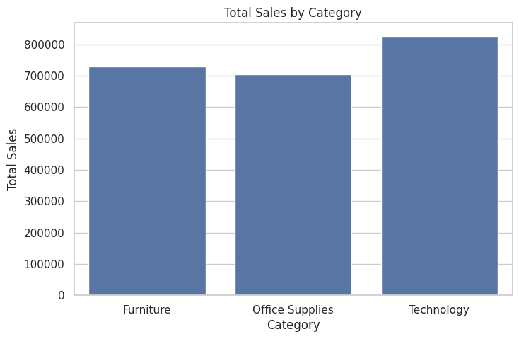

```python
plt.figure(figsize=(8,5))
sns.barplot(x="Category", y="Sales", data=df, estimator=sum, errorbar=None)
plt.title("Total Sales by Category")
plt.ylabel("Total Sales")
plt.show()
```

## **Sales by Category**

- Technology sales are the category with the highest total sales, exceeding $800,000.

-Furniture and Office Supplies have similar sales, around $700,000, but slightly lower than Technology.

conclusion:

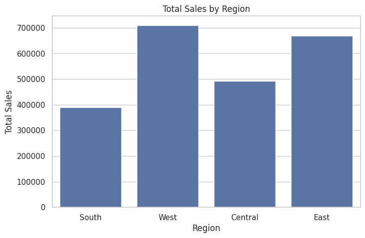

```python
plt.figure(figsize=(8,5))
sns.barplot(x="Region", y="Sales", data=df, estimator=sum, errorbar=None)
plt.title("Total Sales by Region")
plt.ylabel("Total Sales")
plt.show()
```

## **Sales by Region**

- West leads in sales with over $700,000.
- East also has high sales, close to $670,000.
- Central and especially the South have much lower sales (the South does not reach $400,000).

**Conclusion:**

- The West region is the strongest, followed by the East.
- The South and Central regions have growth potential; it would be useful to analyze the factors affecting their lower performance.

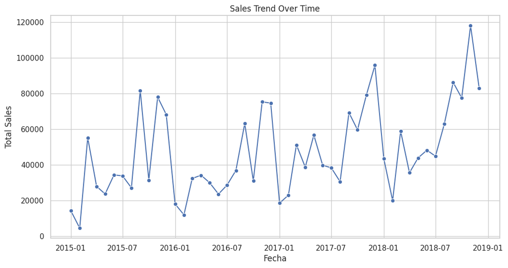

```python
ventas_mensuales = df.groupby(["Order_Year", "Order_Month"])["Sales"].sum().reset_index()
ventas_mensuales["Fecha"] = pd.to_datetime(ventas_mensuales["Order_Year"].astype(str) + "-" + ventas_mensuales["Order_Month"].astype(str))
plt.figure(figsize=(12,6))
sns.lineplot(x="Fecha", y="Sales", data=ventas_mensuales, marker="o")
plt.title("Sales Trend Over Time")
plt.ylabel("Total Sales")
plt.show()
```

## **Sales Trend Over Time**

The highest peak occurs near the end of 2018, exceeding $115,000 in a single period.

**Conclusion:**

Sales show a clear upward trend despite seasonal fluctuations.

This indicates sustained business growth.

**Preparacion del modelado y separación de variables**

```python
# Separating the Variables
X = df[["Ship Mode", "Segment", "Region", "Category", "Sub-Category"]]
y = df["Sales"]

# Splitting into Train/Test Sets
X_train, X_test, y_train, y_test = train_test_split(X, y, test_size=0.2, random_state=42)

# Preprocessing
categorical_features = X.columns
preprocessor = ColumnTransformer(
    transformers=[
        ("cat", OneHotEncoder(handle_unknown="ignore"), categorical_features)
    ]
)
```

**Random Forest Regressor Model**

```python
model_rf = Pipeline(steps=[
    ("preprocessor", preprocessor),
    ("regressor", RandomForestRegressor(n_estimators=200, random_state=42))
])

model_rf.fit(X_train, y_train)
y_pred_rf = model_rf.predict(X_test)

print("Random Forest Regressor:")
print("MAE:", mean_absolute_error(y_test, y_pred_rf))
print("RMSE:", np.sqrt(mean_squared_error(y_test, y_pred_rf)))
print("R2:", r2_score(y_test, y_pred_rf))
```

```
Random Forest Regressor:
MAE: 246.67775375231932
RMSE: 778.5977799897113
R2: 0.09303608212177206
```

**Feature Importance**

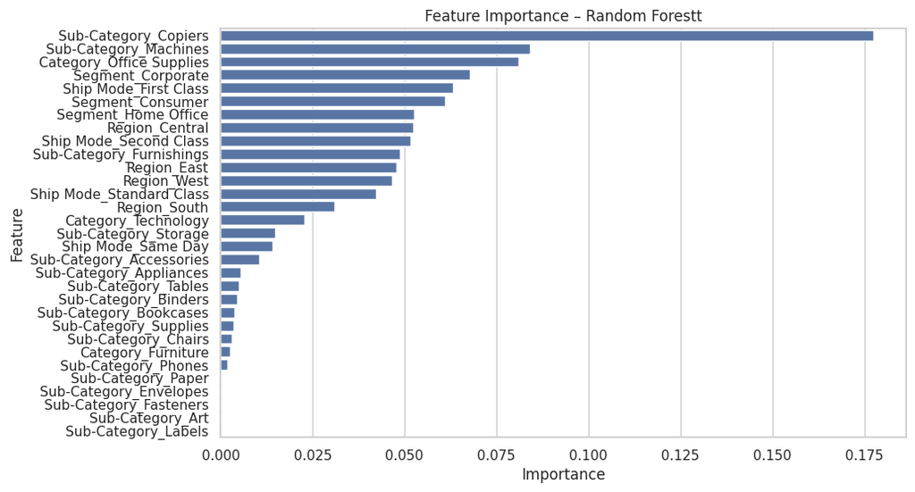

```python
importances = model_rf.named_steps['regressor'].feature_importances_
feature_names = model_rf.named_steps['preprocessor'].transformers_[0][1].get_feature_names_out(categorical_features)

importance_df = pd.DataFrame({'Feature': feature_names, 'Importance': importances})
importance_df = importance_df.sort_values(by='Importance', ascending=False)

sns.barplot(x='Importance', y='Feature', data=importance_df)
plt.title("Feature Importance – Random Forestt")
plt.show()
```

# **Conclusions::**

**The subcategories Copiers and Machines are the most important.**

**The Office Supplies category is also relevant.**

**Geographic Region**

**Low-Importance Variables**

- Subcategories such as Labels, Art, Fasteners, Envelopes, among others, have very little influence on the predictions. This indicates that they could be removed in future versions of the model without affecting its performance.

```python
from google.colab import files
```

```python
uploaded = files.upload()
```

Upload widget is only available when the cell has been executed in the current browser session. Please rerun this cell to enable.

```python
!jupyter nbconvert --to html --output="proyecto_ing_2.html" "proyecto_ing_2.ipynb"
```

```python
files.download("proyecto_ing_2.html")
```